# Part I - Prosper Loan Analysis

## Introduction

> This data set contains 113,937 loans with 81 variables on each loan, including loan amount, borrower rate (or interest rate), current loan status, borrower income, and many others.

## Preliminary Wrangling

```python
# import all packages and set plots to be embedded inline
import numpy as np
import pandas as pd
import matplotlib.pyplot as plt
import seaborn as sb

%matplotlib inline
```

```python
# loading the dataset
loan_df = pd.read_csv("prosperLoanData.csv")
```

```python
loan_df.info()
```

```
<class 'pandas.core.frame.DataFrame'>
RangeIndex: 113937 entries, 0 to 113936
Data columns (total 81 columns):
ListingKey                             113937 non-null object
ListingNumber                          113937 non-null int64
ListingCreationDate                    113937 non-null object
CreditGrade                            28953 non-null object
Term                                   113937 non-null int64
LoanStatus                             113937 non-null object
ClosedDate                             55089 non-null object
BorrowerAPR                            113912 non-null float64
BorrowerRate                           113937 non-null float64
LenderYield                            113937 non-null float64
EstimatedEffectiveYield                84853 non-null float64
EstimatedLoss                          84853 non-null float64
EstimatedReturn                        84853 non-null float64
ProsperRating (numeric)                84853 non-null float64
ProsperRating (Alpha)                  84853 non-null object
ProsperScore                           84853 non-null float64
ListingCategory (numeric)              113937 non-null int64
BorrowerState                          108422 non-null object
Occupation                             110349 non-null object
EmploymentStatus                       111682 non-null object
EmploymentStatusDuration               106312 non-null float64
IsBorrowerHomeowner                    113937 non-null bool
CurrentlyInGroup                       113937 non-null bool
GroupKey                               13341 non-null object
DateCreditPulled                       113937 non-null object
CreditScoreRangeLower                  113346 non-null float64
CreditScoreRangeUpper                  113346 non-null float64
FirstRecordedCreditLine                113240 non-null object
CurrentCreditLines                     106333 non-null float64
OpenCreditLines                        106333 non-null float64
TotalCreditLinespast7years             113240 non-null float64
OpenRevolvingAccounts                  113937 non-null int64
OpenRevolvingMonthlyPayment            113937 non-null float64
InquiriesLast6Months                   113240 non-null float64
TotalInquiries                         112778 non-null float64
CurrentDelinquencies                   113240 non-null float64
AmountDelinquent                       106315 non-null float64
```

[output cut: 31 more lines]

```
LP_CustomerPayments                    113937 non-null float64
LP_CustomerPrincipalPayments           113937 non-null float64
LP_InterestandFees                     113937 non-null float64
LP_ServiceFees                         113937 non-null float64
LP_CollectionFees                      113937 non-null float64
LP_GrossPrincipalLoss                  113937 non-null float64
LP_NetPrincipalLoss                    113937 non-null float64
LP_NonPrincipalRecoverypayments        113937 non-null float64
PercentFunded                          113937 non-null float64
Recommendations                        113937 non-null int64
InvestmentFromFriendsCount             113937 non-null int64
InvestmentFromFriendsAmount            113937 non-null float64
Investors                              113937 non-null int64
dtypes: bool(3), float64(50), int64(11), object(17)
memory usage: 68.1+ MB
```

```python
loan_df.describe()
```

|  | ListingNumber | Term | BorrowerAPR | BorrowerRate | LenderYield | EstimatedEffectiveYield | EstimatedLoss | EstimatedReturn | ProsperRating (numeric) | ProsperScore | ... | LP_ServiceFees | LP_CollectionFees | LP_GrossPrincipalLoss | LP_NetPrincipalLoss | LP_NonPrincipalRecoverypayments | PercentFunded | Recommendations | InvestmentFromFriendsCount | InvestmentFromFriendsAmount | Investors |
| --- | --- | --- | --- | --- | --- | --- | --- | --- | --- | --- | --- | --- | --- | --- | --- | --- | --- | --- | --- | --- | --- |
| count | 1.139370e+05 | 113937.000000 | 113912.000000 | 113937.000000 | 113937.000000 | 84853.000000 | 84853.000000 | 84853.000000 | 84853.000000 | 84853.000000 | ... | 113937.000000 | 113937.000000 | 113937.000000 | 113937.000000 | 113937.000000 | 113937.000000 | 113937.000000 | 113937.000000 | 113937.000000 | 113937.000000 |
| mean | 6.278857e+05 | 40.830248 | 0.218828 | 0.192764 | 0.182701 | 0.168661 | 0.080306 | 0.096068 | 4.072243 | 5.950067 | ... | -54.725641 | -14.242698 | 700.446342 | 681.420499 | 25.142686 | 0.998584 | 0.048027 | 0.023460 | 16.550751 | 80.475228 |
| std | 3.280762e+05 | 10.436212 | 0.080364 | 0.074818 | 0.074516 | 0.068467 | 0.046764 | 0.030403 | 1.673227 | 2.376501 | ... | 60.675425 | 109.232758 | 2388.513831 | 2357.167068 | 275.657937 | 0.017919 | 0.332353 | 0.232412 | 294.545422 | 103.239020 |
| min | 4.000000e+00 | 12.000000 | 0.006530 | 0.000000 | -0.010000 | -0.182700 | 0.004900 | -0.182700 | 1.000000 | 1.000000 | ... | -664.870000 | -9274.750000 | -94.200000 | -954.550000 | 0.000000 | 0.700000 | 0.000000 | 0.000000 | 0.000000 | 1.000000 |
| 25% | 4.009190e+05 | 36.000000 | 0.156290 | 0.134000 | 0.124200 | 0.115670 | 0.042400 | 0.074080 | 3.000000 | 4.000000 | ... | -73.180000 | 0.000000 | 0.000000 | 0.000000 | 0.000000 | 1.000000 | 0.000000 | 0.000000 | 0.000000 | 2.000000 |
| 50% | 6.005540e+05 | 36.000000 | 0.209760 | 0.184000 | 0.173000 | 0.161500 | 0.072400 | 0.091700 | 4.000000 | 6.000000 | ... | -34.440000 | 0.000000 | 0.000000 | 0.000000 | 0.000000 | 1.000000 | 0.000000 | 0.000000 | 0.000000 | 44.000000 |
| 75% | 8.926340e+05 | 36.000000 | 0.283810 | 0.250000 | 0.240000 | 0.224300 | 0.112000 | 0.116600 | 5.000000 | 8.000000 | ... | -13.920000 | 0.000000 | 0.000000 | 0.000000 | 0.000000 | 1.000000 | 0.000000 | 0.000000 | 0.000000 | 115.000000 |
| max | 1.255725e+06 | 60.000000 | 0.512290 | 0.497500 | 0.492500 | 0.319900 | 0.366000 | 0.283700 | 7.000000 | 11.000000 | ... | 32.060000 | 0.000000 | 25000.000000 | 25000.000000 | 21117.900000 | 1.012500 | 39.000000 | 33.000000 | 25000.000000 | 1189.000000 |

8 rows × 61 columns

```python
loan_df.head()
```

|  | ListingKey | ListingNumber | ListingCreationDate | CreditGrade | Term | LoanStatus | ClosedDate | BorrowerAPR | BorrowerRate | LenderYield | ... | LP_ServiceFees | LP_CollectionFees | LP_GrossPrincipalLoss | LP_NetPrincipalLoss | LP_NonPrincipalRecoverypayments | PercentFunded | Recommendations | InvestmentFromFriendsCount | InvestmentFromFriendsAmount | Investors |
| --- | --- | --- | --- | --- | --- | --- | --- | --- | --- | --- | --- | --- | --- | --- | --- | --- | --- | --- | --- | --- | --- |
| 0 | 1021339766868145413AB3B | 193129 | 2007-08-26 19:09:29.263000000 | C | 36 | Completed | 2009-08-14 00:00:00 | 0.16516 | 0.1580 | 0.1380 | ... | -133.18 | 0.0 | 0.0 | 0.0 | 0.0 | 1.0 | 0 | 0 | 0.0 | 258 |
| 1 | 10273602499503308B223C1 | 1209647 | 2014-02-27 08:28:07.900000000 | NaN | 36 | Current | NaN | 0.12016 | 0.0920 | 0.0820 | ... | 0.00 | 0.0 | 0.0 | 0.0 | 0.0 | 1.0 | 0 | 0 | 0.0 | 1 |
| 2 | 0EE9337825851032864889A | 81716 | 2007-01-05 15:00:47.090000000 | HR | 36 | Completed | 2009-12-17 00:00:00 | 0.28269 | 0.2750 | 0.2400 | ... | -24.20 | 0.0 | 0.0 | 0.0 | 0.0 | 1.0 | 0 | 0 | 0.0 | 41 |
| 3 | 0EF5356002482715299901A | 658116 | 2012-10-22 11:02:35.010000000 | NaN | 36 | Current | NaN | 0.12528 | 0.0974 | 0.0874 | ... | -108.01 | 0.0 | 0.0 | 0.0 | 0.0 | 1.0 | 0 | 0 | 0.0 | 158 |
| 4 | 0F023589499656230C5E3E2 | 909464 | 2013-09-14 18:38:39.097000000 | NaN | 36 | Current | NaN | 0.24614 | 0.2085 | 0.1985 | ... | -60.27 | 0.0 | 0.0 | 0.0 | 0.0 | 1.0 | 0 | 0 | 0.0 | 20 |

5 rows × 81 columns

**NB:** Not all 81 variables contained in the dataset are useful for this analysis. I'll create a subset of the dataset containing the variables relevant to this investigation.

```python
# Create a subset of the dataset using relevant columns
relevant_cols = ['LoanKey', 'Term','LoanOriginalAmount','LoanOriginationDate', 'ListingNumber',
                 'LoanStatus','ListingCategory (numeric)','BorrowerAPR','BorrowerRate',
                 'BorrowerState' , 'CreditGrade', 'EmploymentStatus','StatedMonthlyIncome',
                 'MonthlyLoanPayment', 'ProsperRating (Alpha)', 'IncomeRange', 'TotalProsperLoans',
                 'Recommendations','Investors','DelinquenciesLast7Years']
subset_df = loan_df[relevant_cols]
```

```python
# Check the structure of the dataset
subset_df.info()
```

```
<class 'pandas.core.frame.DataFrame'>
RangeIndex: 113937 entries, 0 to 113936
Data columns (total 20 columns):
LoanKey                      113937 non-null object
Term                         113937 non-null int64
LoanOriginalAmount           113937 non-null int64
LoanOriginationDate          113937 non-null object
ListingNumber                113937 non-null int64
LoanStatus                   113937 non-null object
ListingCategory (numeric)    113937 non-null int64
BorrowerAPR                  113912 non-null float64
BorrowerRate                 113937 non-null float64
BorrowerState                108422 non-null object
CreditGrade                  28953 non-null object
EmploymentStatus             111682 non-null object
StatedMonthlyIncome          113937 non-null float64
MonthlyLoanPayment           113937 non-null float64
ProsperRating (Alpha)        84853 non-null object
IncomeRange                  113937 non-null object
TotalProsperLoans            22085 non-null float64
Recommendations              113937 non-null int64
Investors                    113937 non-null int64
DelinquenciesLast7Years      112947 non-null float64
dtypes: float64(6), int64(6), object(8)
memory usage: 17.4+ MB
```

```python
subset_df.describe()
```

|  | Term | LoanOriginalAmount | ListingNumber | ListingCategory (numeric) | BorrowerAPR | BorrowerRate | StatedMonthlyIncome | MonthlyLoanPayment | TotalProsperLoans | Recommendations | Investors | DelinquenciesLast7Years |
| --- | --- | --- | --- | --- | --- | --- | --- | --- | --- | --- | --- | --- |
| count | 113937.000000 | 113937.00000 | 1.139370e+05 | 113937.000000 | 113912.000000 | 113937.000000 | 1.139370e+05 | 113937.000000 | 22085.000000 | 113937.000000 | 113937.000000 | 112947.000000 |
| mean | 40.830248 | 8337.01385 | 6.278857e+05 | 2.774209 | 0.218828 | 0.192764 | 5.608026e+03 | 272.475783 | 1.421100 | 0.048027 | 80.475228 | 4.154984 |
| std | 10.436212 | 6245.80058 | 3.280762e+05 | 3.996797 | 0.080364 | 0.074818 | 7.478497e+03 | 192.697812 | 0.764042 | 0.332353 | 103.239020 | 10.160216 |
| min | 12.000000 | 1000.00000 | 4.000000e+00 | 0.000000 | 0.006530 | 0.000000 | 0.000000e+00 | 0.000000 | 0.000000 | 0.000000 | 1.000000 | 0.000000 |
| 25% | 36.000000 | 4000.00000 | 4.009190e+05 | 1.000000 | 0.156290 | 0.134000 | 3.200333e+03 | 131.620000 | 1.000000 | 0.000000 | 2.000000 | 0.000000 |
| 50% | 36.000000 | 6500.00000 | 6.005540e+05 | 1.000000 | 0.209760 | 0.184000 | 4.666667e+03 | 217.740000 | 1.000000 | 0.000000 | 44.000000 | 0.000000 |
| 75% | 36.000000 | 12000.00000 | 8.926340e+05 | 3.000000 | 0.283810 | 0.250000 | 6.825000e+03 | 371.580000 | 2.000000 | 0.000000 | 115.000000 | 3.000000 |
| max | 60.000000 | 35000.00000 | 1.255725e+06 | 20.000000 | 0.512290 | 0.497500 | 1.750003e+06 | 2251.510000 | 8.000000 | 39.000000 | 1189.000000 | 99.000000 |

```python
# rename certain columns to display the dataframe more cleanly
subset_df.rename(columns={'ListingCategory (numeric)': 'ListingCategory', 'ProsperRating (Alpha)': 'ProsperRating'}, inplace=True);
```

Reduce the number of rows in the dataframe by removing the null values in the ProsperRating column

```python
subset_df = subset_df[subset_df['ProsperRating'].notna()]
```

```python
# convert the LoanOriginationDate columns to a Datetime datatype
subset_df['LoanOriginationDate'] = pd.to_datetime(subset_df['LoanOriginationDate'])
```

TotalProsperLoans values are significantly lower than the other variables in the dataset, we'll need to fill in its empty rows with an arbitrary value - 0

```python
subset_df['TotalProsperLoans'] = subset_df['TotalProsperLoans'].fillna(0)
```

Since the LoanKey is a unique identifier for each loan, we'll be using this as the index

```python
subset_df.set_index('LoanKey', inplace=True)
```

```python
# Display the count of the various income ranges
subset_df.IncomeRange.value_counts()
```

```
$50,000-74,999    25627
$25,000-49,999    24175
$100,000+         15205
$75,000-99,999    14498
$1-24,999          4654
Not employed        649
$0                   45
Name: IncomeRange, dtype: int64
```

```python
# replace the $0 income range category with "Not Employed"
subset_df.IncomeRange.replace({'$0': 'Not employed'}, inplace=True);
```

```python
# Display the count of the various employment status
subset_df.EmploymentStatus.value_counts()
```

```
Employed         67310
Full-time         7927
Self-employed     4538
Other             3806
Not employed       649
Retired            367
Part-time          256
Name: EmploymentStatus, dtype: int64
```

```python
# Display the count of the Prosper ratings

subset_df.ProsperRating.value_counts()
```

```
C     18345
B     15581
A     14551
D     14274
E      9795
HR     6935
AA     5372
Name: ProsperRating, dtype: int64
```

```python
# Reorder the IncomeRange , EmploymentStatus, ProsperRating columns as ordered categorical variables
inc_dict = {'IncomeRange': ['Not displayed', 'Not employed', '$1-24,999',
                           '$25,000-49,999', '$50,000-74,999', '$75,000-99,999', '$100,000+'],
           'EmploymentStatus': ['Employed', 'Self-employed', 'Full-time',
                                'Part-time', 'Other', 'Retired'],
           'ProsperRating':['HR', 'E', 'D', 'C', 'B', 'A', 'AA']}
for i in inc_dict:
    order = pd.api.types.CategoricalDtype(ordered=True, categories = inc_dict[i])
    subset_df[i] = subset_df[i].astype(order);
```

### The structure of the dataset

> The main data set contains 113,937 loans with 81 variables

### The main features of interest in the dataset

> My investigation aims to answer the following questions:
> 1. What features can be used to explain/predict default on credit?
> 2. What correlation exists between the number of loans and income range?
> 3. What is the relationship between borrower rate and loan amount?

### What features in the dataset do you think will help support your investigation into your features of interest?

> The Prosper rating and employment status will be essential in investigating the possiblity of default. Other useful features in the data are the loan amount and terms, borrower rate and income.

## Univariate Exploration

### Loan Status - The current status of the loan

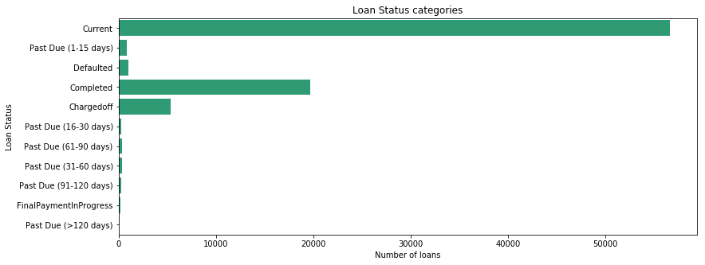

```python
# Setting preferred color for all plots
p_color = '#1dad79'

# Set the figure size
fig, ax = plt.subplots(figsize=(13, 5))

# Plot the Loan Status variable
ls = sb.countplot(data=subset_df, y='LoanStatus', color=p_color);
ls.set(title ='Loan Status categories', xlabel = 'Number of loans', ylabel='Loan Status');
```

### Observation:

- Most of the loans in the data set are current loans, followed by completed and charged-off loans.
- There are 5 groups of **Past due loans** which are split based on the length of delay in repayment.
- The defaulted loans are quite few

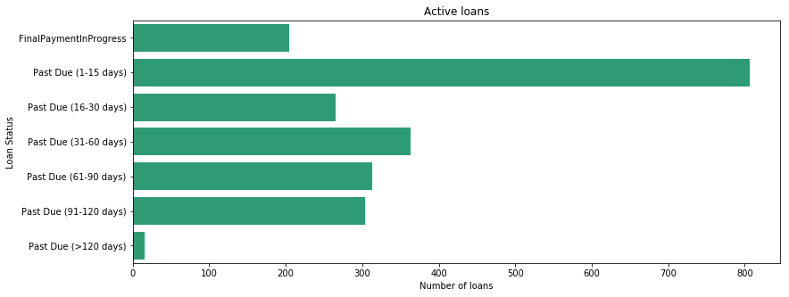

```python
# Set the figure size
fig, ax = plt.subplots(figsize=(13, 5))

# Exploring the distribution of active loans (current status excluded)
order = ['FinalPaymentInProgress', 'Past Due (1-15 days)', 'Past Due (16-30 days)', \
         'Past Due (31-60 days)', 'Past Due (61-90 days)', 'Past Due (91-120 days)',
         'Past Due (>120 days)']
ls2 = sb.countplot(data = subset_df[subset_df.LoanStatus.isin(order)], y = 'LoanStatus',
             order = order, color = p_color, orient = 'h')
ls2.set(title = 'Active loans',xlabel = 'Number of loans', ylabel='Loan Status');
```

### Employment Status - The employment status of the borrower at the time they posted the listing.

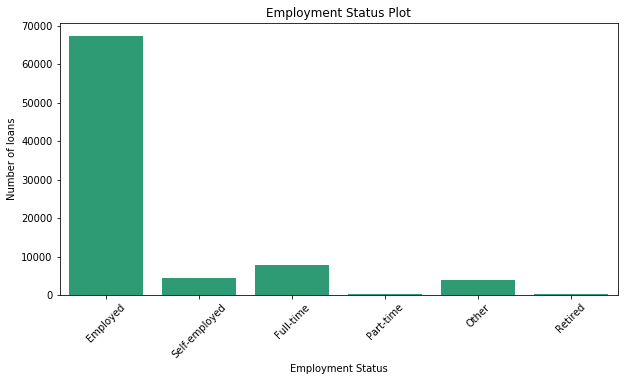

```python
# Set the figure size
fig, ax = plt.subplots(figsize=(10, 5))


#Plot the employment status variable
es = sb.countplot(data = subset_df, x = 'EmploymentStatus', color=p_color)
plt.xticks(rotation=45);
es.set(title ='Employment Status Plot', xlabel = 'Employment Status', ylabel='Number of loans');
```

### Observation

- Most of the borrowers are employed. The dataset contains a significant number of people in full-time employment. - - The population of people that are self-employed is slightly higher than those in other forms of employment.
- The number of retired and part-time employed people is quite low

### Income Range - The income range of the borrower at the time the listing was created.

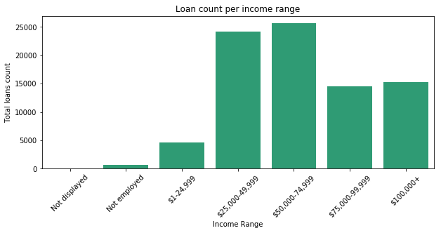

```python
# Set the figure size
fig, ax = plt.subplots(figsize=(10, 4))


#Plot the income range variable
es = sb.countplot(data = subset_df, x = 'IncomeRange', color=p_color)
plt.xticks(rotation=45);
es.set(title ='Loan count per income range', xlabel = 'Income Range', ylabel='Total loans count');
```

### Observation

- People that earn between \$50,000 and \\$75,000 take the most loans, they're closely followed by those in the \$25,000 - \\$49,999 income range.
- A significant number of borrowers are in the \$75,000 - \\$100,000+ income range and they have the second largest number of loans after the aforementioned income range

### Total Prosper Loans - Number of loans the borrower had at the time this listing was created.

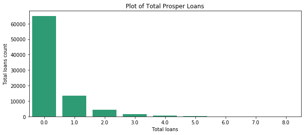

```python
# Set the figure size
fig, ax = plt.subplots(figsize=(10, 4))


#Plot the total of Prosper Loans
tpl = sb.countplot(data = subset_df, x = 'TotalProsperLoans', color=p_color)
tpl.set(title ='Plot of Total Prosper Loans', xlabel = 'Total loans', ylabel='Total loans count');
```

### Observation

- Most of the individuals were first-time borrowers with Prosper, they had no prior loans at the time of this listing.
- A significant number of borrowers had only 1 prior loan while a few individuals had 2+ prior loans

### Borrower Rate - The interest rate for a loan.

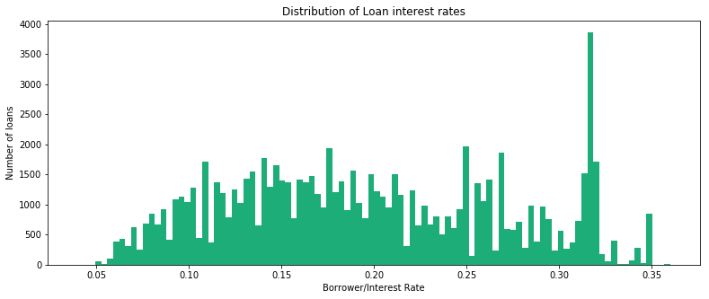

```python
# Set the figure size
fig, ax = plt.subplots(figsize=(13, 5))

# Plot the interest rates for the loans
plt.hist(data = subset_df, x = 'BorrowerRate', color=p_color, bins = 100);
plt.xlabel('Borrower/Interest Rate');
plt.ylabel('Number of loans');
plt.title('Distribution of Loan interest rates');
```

### Observation

- The interest rate is left-skewed with a sharp peak around 0.32 for ~4,000 loans
- The largest number of loans come with the interest rates between 0.1 and 0.3
- There are a few loans with interest rates less than 0.1

### Borrower State - The two letter abbreviation of the state of the address of the borrower

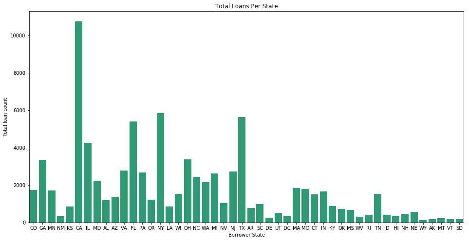

```python
# Set the figure size
fig, ax = plt.subplots(figsize=(16, 8))


# Borrower State plot
bs = sb.countplot(data = subset_df, x = 'BorrowerState', color=p_color)
bs.set(title ='Total Loans Per State', xlabel = 'Borrower State',
       ylabel='Total loan count');
```

### Observation

- Most of the borrowers live in California while Wyoming has the fewest number of borrowers.

### Terms - The length of a loan in months.

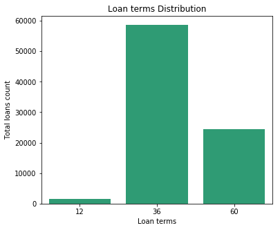

```python
# Set the figure size
fig, ax = plt.subplots(figsize=(6, 5))

# plot the loan terms
lt = sb.countplot(data = subset_df, x = 'Term', color = p_color);
lt.set(title ='Loan terms Distribution', xlabel = 'Loan terms', ylabel='Total loans count');
```

### Observation

- There are only 3 distinct loan terms: 12, 36 and 60 months
- Most loans are for 36 months.

### Of the features you investigated, were there any unusual distributions? Did you perform any operations on the data to tidy, adjust, or change the form of the data? If so, why did you do this?

> There was a sharp peak in the interest rate around 0.32 which was significantly higher than the other interest rates. I created a subset of the main dataset to make investigation easier. Some columms were renamed to ensure that the data set is neatly displayed. Null values in the Prosper rating column were dropped as they'd affect the analysis being conducted. The IncomeRange , EmploymentStatus, ProsperRating columns were also reordered to allow for them to be displayed appropriately as categorical variables.

## Bivariate Exploration

### Loan Status and Prosper Rating

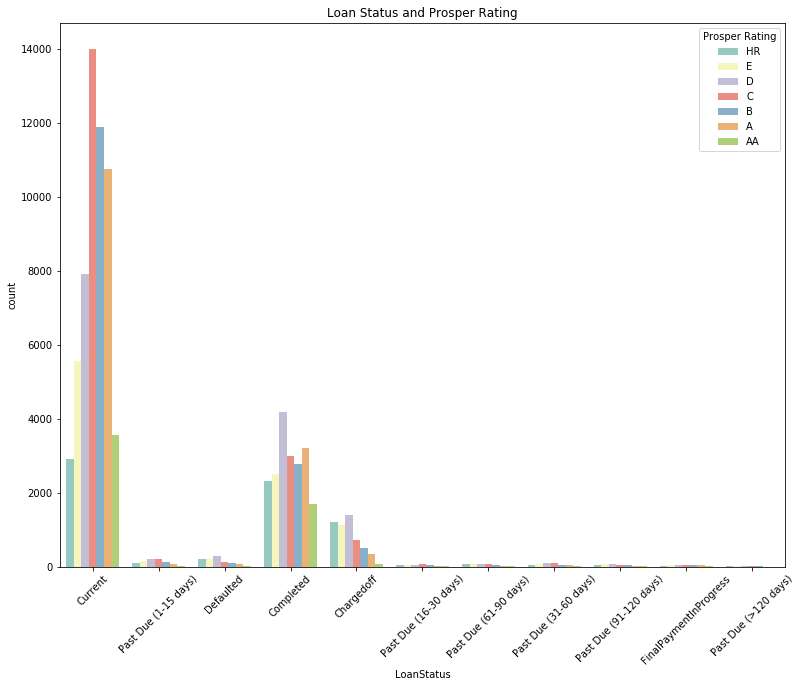

```python
# Set the figure size
fig, ax = plt.subplots(figsize=(13, 10))

plot = sb.countplot(data = subset_df, x = 'LoanStatus', hue = 'ProsperRating', palette = 'Set3');
plot.set(title='Loan Status and Prosper Rating');
plt.xticks(rotation=45);
plt.legend(title = 'Prosper Rating', loc='upper right');
```

### Observation

- Most of the current loans have the rating - C
- Most of the completed and chargedoff loans have the rating - D

### Borrower Rate and Loan Original Amount

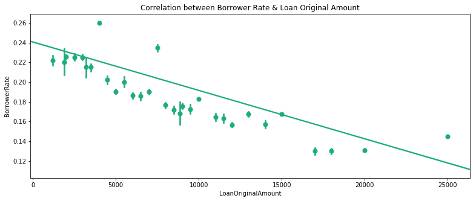

```python
# Set the figure size
fig, ax = plt.subplots(figsize=(13, 5))

sb.regplot(data = subset_df, x = 'LoanOriginalAmount', y = 'BorrowerRate', x_bins = 100,
           color=p_color).set(title='Correlation between Borrower Rate & Loan Original Amount');
```

### Observation

- There's a negative correlation between the Borrower Rate and Loan Original Amount

### Loan Amount and the Monthly payment

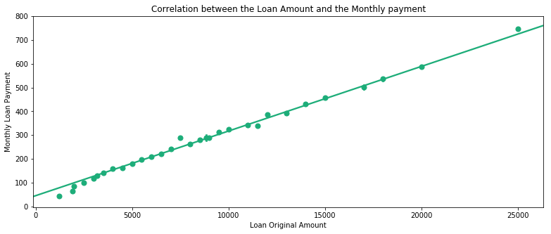

```python
# correlation between the Loan Amount and the Monthly payment
fig, ax = plt.subplots(figsize=(13, 5));

la_mp = sb.regplot(data = subset_df, x = 'LoanOriginalAmount', y = 'MonthlyLoanPayment',
           x_bins = 100, color=p_color)

la_mp.set(title ='Correlation between the Loan Amount and the Monthly payment',
          xlabel = 'Loan Original Amount', ylabel='Monthly Loan Payment');
```

### Observation

- There is a positive correlation between the Loan Amount and the Monthly payment

### Loan Original Amount and Borrower State

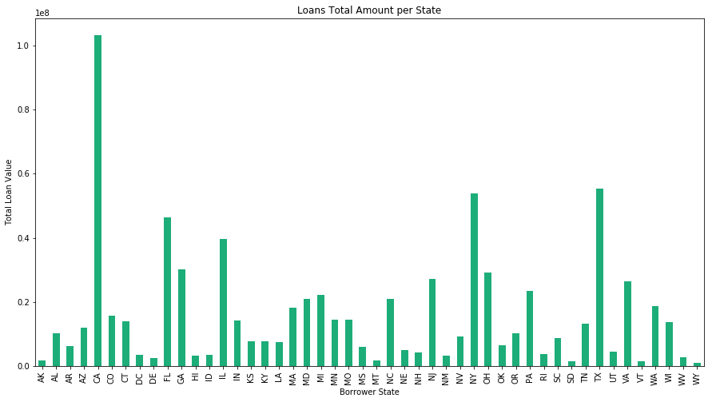

```python
subset_df.groupby(['BorrowerState']).sum()['LoanOriginalAmount'].plot(kind='bar', title= 'Loans Total Amount per State', color=p_color, figsize=(15,8));
plt.xlabel('Borrower State');
plt.ylabel('Total Loan Value');
```

### Observation

California is the state with the highest value of loans taken. This isn't surprising as most of the borrowers live in the state.

### Prosper Rating and Employment Status

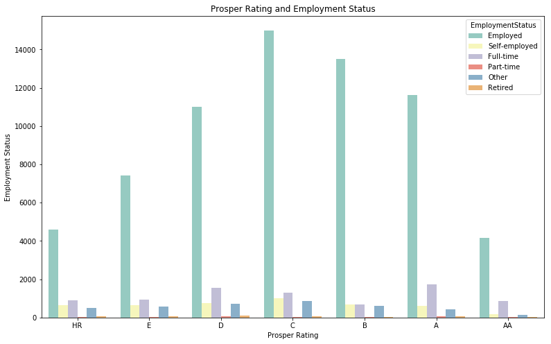

```python
fig, ax = plt.subplots(figsize=(13, 8));
pr_es = sb.countplot(data = subset_df, x = 'ProsperRating', hue = 'EmploymentStatus', palette = 'Set3');
pr_es.set(title ='Prosper Rating and Employment Status',
          xlabel = 'Prosper Rating', ylabel='Employment Status');
```

### Talk about some of the relationships you observed in this part of the investigation. How did the feature(s) of interest vary with other features in the dataset?

> Most of the current loans are rated C while most of the defaulted loans are rated D. There is a positive correlation between the Loan Amount and the Monthly payment and a negative correlation between the Borrower Rate and Loan Original Amount

### Did you observe any interesting relationships between the other features (not the main feature(s) of interest)?

> When analysed with the Prosper ratings, the employment status - Employed, has a normal distribution.

## Multivariate Exploration

### Loan Status, Loan Original Amount and Prosper Rating

```python
# Adjusting the Loan Status to only display Completed and Defaulted loans

setting = (subset_df['LoanStatus'] == 'Completed') | (subset_df['LoanStatus'] == 'Defaulted') |\
                  (subset_df['LoanStatus'] == 'Chargedoff')
subset_df = subset_df[setting]

#define a function to adjust the loan status to 2 values
def change(status):
    if status['LoanStatus'] == 'Chargedoff':
        return 'Defaulted'
    else:
        return status['LoanStatus']

subset_df['LoanStatus'] = subset_df.apply(change, axis=1)
subset_df['LoanStatus'].value_counts()
```

```
Completed    19664
Defaulted     6341
Name: LoanStatus, dtype: int64
```

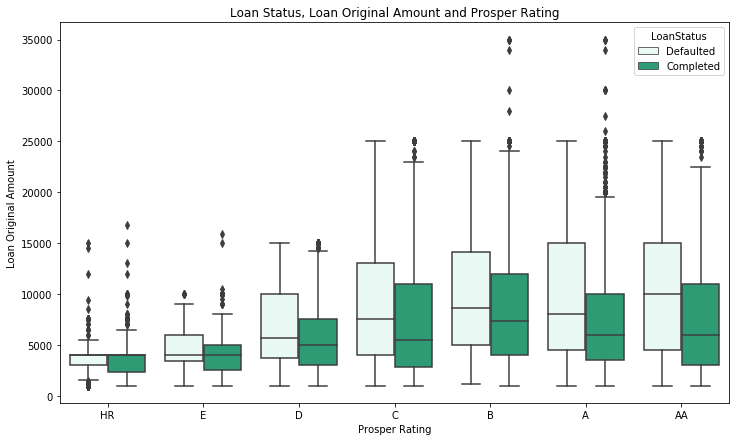

```python
# set figure size
plt.figure(figsize = [12, 7])

pll = sb.boxplot(data=subset_df, x='ProsperRating', y='LoanOriginalAmount', color=p_color , hue='LoanStatus');
pll.set(title ='Loan Status, Loan Original Amount and Prosper Rating',
          xlabel = 'Prosper Rating', ylabel='Loan Original Amount');
```

### Listing Category, Loan Original Amount and Loan Status

```python
Listing_categories = {1: 'Debt Consolidation', 2: 'Home Improvement', 3: 'Business',
                      4: 'Personal Loan', 5: 'Student Use', 6: 'Auto', 7: 'Other'}
def minimize(categories):
    loan_category = categories['ListingCategory']
    if  loan_category in Listing_categories:
        return Listing_categories[loan_category]
    else:
        return Listing_categories[7]

# Check
subset_df['ListingCategory'] = subset_df.apply(minimize, axis=1)
subset_df['ListingCategory'].value_counts()
```

```
Debt Consolidation    12740
Other                  6809
Home Improvement       2612
Business               2366
Auto                   1204
Student Use             274
Name: ListingCategory, dtype: int64
```

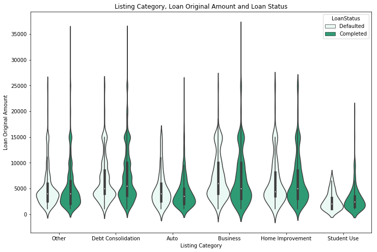

```python
# set figure size
plt.figure(figsize = [12, 8])

lll =sb.violinplot(data=subset_df, x='ListingCategory', y='LoanOriginalAmount', color=p_color, hue='LoanStatus');
lll.set(title ='Listing Category, Loan Original Amount and Loan Status',
          xlabel = 'Listing Category', ylabel='Loan Original Amount');
```

### Loan Origination Year, Borrower APR & Income Range

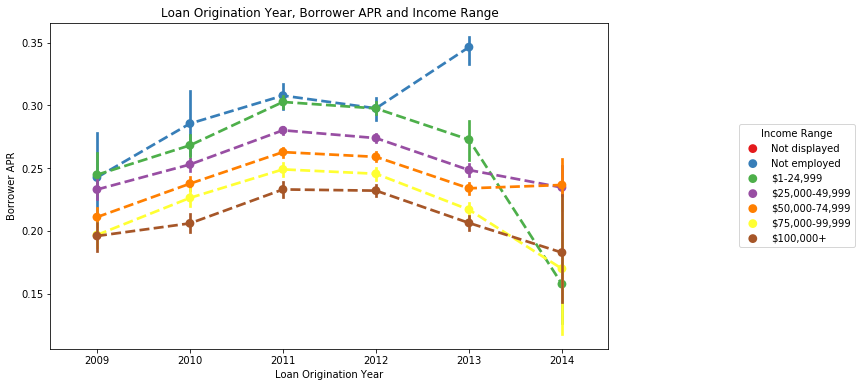

```python
# set figure size
plt.figure(figsize = [10, 6])

lbi = sb.pointplot(data = subset_df, x = subset_df['LoanOriginationDate'].dt.year, y = 'BorrowerAPR', hue = 'IncomeRange', palette = 'Set1',\
             linestyles = '--')
plt.legend(title = 'Income Range', loc = 'right', bbox_to_anchor=(1.45, 0.5), ncol=1);
lbi.set(title ='Loan Origination Year, Borrower APR and Income Range',
          xlabel = 'Loan Origination Year', ylabel='Borrower APR');
```

### Loan Origination Year, Borrower Rate & Income Range

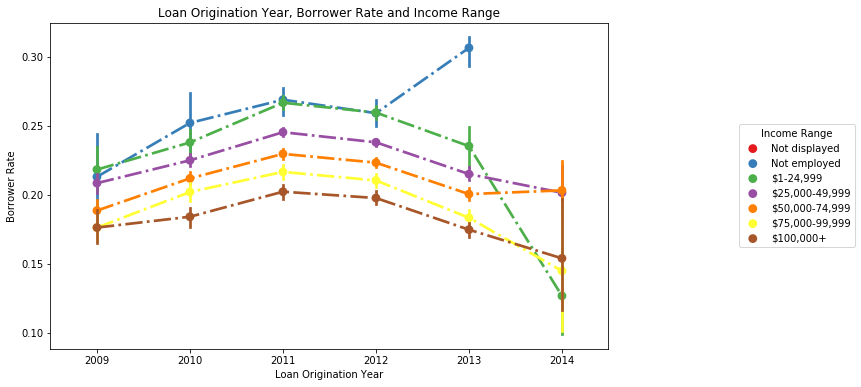

```python
# set figure size
plt.figure(figsize = [10, 6])

b_rate = sb.pointplot(data = subset_df, x = subset_df['LoanOriginationDate'].dt.year, y = 'BorrowerRate', hue = 'IncomeRange', palette = 'Set1',\
             linestyles = '-.')
plt.legend(title = 'Income Range', loc = 'right', bbox_to_anchor=(1.45, 0.5), ncol=1);
b_rate.set(title ='Loan Origination Year, Borrower Rate and Income Range',
          xlabel = 'Loan Origination Year', ylabel='Borrower Rate');
```

### Observation

- Borrower Rate and APR have a similar behaviour with the variables: Loan Origination year and Income Range

### Loan Origination Year, Loan Original Amount & Income Range

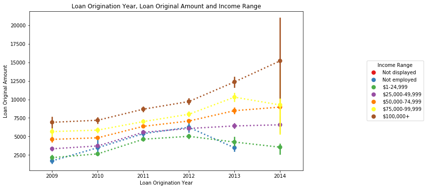

```python
# set figure size
plt.figure(figsize = [10, 6])

lli = sb.pointplot(data = subset_df, x = subset_df['LoanOriginationDate'].dt.year, y = 'LoanOriginalAmount', hue = 'IncomeRange', \
             palette = 'Set1', linestyles = ':')
plt.legend(title = 'Income Range', loc = 'right', bbox_to_anchor=(1.45, 0.5), ncol=1);
lli.set(title ='Loan Origination Year, Loan Original Amount and Income Range',
          xlabel = 'Loan Origination Year', ylabel='Loan Original Amount');
```

### Observation

- The loan original amount steadily increased from 2009 to 2012 for all income groups. The unemployed borrowers had a sharp drop in their loan original amounts in 2013.
- These 3 incomes groups ( \$100,000+, \\$25,000 - \$49,999, \\$50,000 - \$74,999) - had an increase in their original loan amounts for every year under review

## Conclusions

> A significant number of borrowers had only 1 prior loan while a few individuals had 2+ prior loans. Of the 3 available loan terms, the 36 month tenor was the most-preferred. The loan original amount steadily increased from 2009 to 2012 for all income groups. In 2013, the unemployed borrowers had a sharp drop in their loan original amounts.

> For multivariate exploration, the loan status was modified to display completed and defaulted loans. It was interesting to see that the defaulted loans for individuals with high Prosper ratings tend to be larger than completed loans. One would expect that these individuals would have a higher number of completed loans since the data suggests that they earn more than the others.